# PURR Summary

2019-10-10, 15:21:12

# 1 PURR: Pipeline for UMII/RIS RNASeq Analysis

[figure not shown]

PURR is the RNASeq analysis pipeline that is housed within CHURP, the **C**ollection of **H**ierarchical **U**MII/**R**IS **P**ipelines. CHURP is developed and maintained by the Research Informatics Solutions (RIS) group at MSI with funding provided by the University of Minnesota Informatics Institute (UMII).

https://www.msi.umn.edu/

https://research.umn.edu/units/umii

# 2 Key Figures and Summaries

## 2.1 Experiment Summary

The location of the FASTQ files for this run is `/panfs/roc/groups/14/msistaff/public/RNAseq_Tutorial/Reads`

This run consists of `8` samples.

A tabular summary of the samples and reads that were analyzed is shown below:

|  | Sample Name | Group | R1 | R2 | Trim? | Remove Dups? | Trim Options | Strand |
| --- | --- | --- | --- | --- | --- | --- | --- | --- |
| 1 | BoneMarrow-1 | B | BoneMarrow-1_S23_R1_001.fastq.gz | BoneMarrow-1_S23_R2_001.fastq.gz | yes | no | ILLUMINACLIP:$TRIMMOMATIC/adapters/all_illumina_adapters.fa:4:15:7:2:true LEADING:3 TRAILING:3 SLIDINGWINDOW:4:15 MINLEN:18 | 0 |
| 2 | BoneMarrow-2 | S | BoneMarrow-2_S21_R1_001.fastq.gz | BoneMarrow-2_S21_R2_001.fastq.gz | yes | no | ILLUMINACLIP:$TRIMMOMATIC/adapters/all_illumina_adapters.fa:4:15:7:2:true LEADING:3 TRAILING:3 SLIDINGWINDOW:4:15 MINLEN:18 | 0 |
| 3 | BoneMarrow-3 | B | BoneMarrow-3_S19_R1_001.fastq.gz | BoneMarrow-3_S19_R2_001.fastq.gz | yes | no | ILLUMINACLIP:$TRIMMOMATIC/adapters/all_illumina_adapters.fa:4:15:7:2:true LEADING:3 TRAILING:3 SLIDINGWINDOW:4:15 MINLEN:18 | 0 |
| 4 | BoneMarrow-4 | B | BoneMarrow-4_S17_R1_001.fastq.gz | BoneMarrow-4_S17_R2_001.fastq.gz | yes | no | ILLUMINACLIP:$TRIMMOMATIC/adapters/all_illumina_adapters.fa:4:15:7:2:true LEADING:3 TRAILING:3 SLIDINGWINDOW:4:15 MINLEN:18 | 0 |
| 5 | Spleen-1 | S | Spleen-1_S31_R1_001.fastq.gz | Spleen-1_S31_R2_001.fastq.gz | yes | no | ILLUMINACLIP:$TRIMMOMATIC/adapters/all_illumina_adapters.fa:4:15:7:2:true LEADING:3 TRAILING:3 SLIDINGWINDOW:4:15 MINLEN:18 | 0 |
| 6 | Spleen-2 | S | Spleen-2_S29_R1_001.fastq.gz | Spleen-2_S29_R2_001.fastq.gz | yes | no | ILLUMINACLIP:$TRIMMOMATIC/adapters/all_illumina_adapters.fa:4:15:7:2:true LEADING:3 TRAILING:3 SLIDINGWINDOW:4:15 MINLEN:18 | 0 |
| 7 | Spleen-3 | S | Spleen-3_S27_R1_001.fastq.gz | Spleen-3_S27_R2_001.fastq.gz | yes | no | ILLUMINACLIP:$TRIMMOMATIC/adapters/all_illumina_adapters.fa:4:15:7:2:true LEADING:3 TRAILING:3 SLIDINGWINDOW:4:15 MINLEN:18 | 0 |
| 8 | Spleen-4 | S | Spleen-4_S25_R1_001.fastq.gz | Spleen-4_S25_R2_001.fastq.gz | yes | no | ILLUMINACLIP:$TRIMMOMATIC/adapters/all_illumina_adapters.fa:4:15:7:2:true LEADING:3 TRAILING:3 SLIDINGWINDOW:4:15 MINLEN:18 | 0 |

## 2.2 Fragment Counts Plot

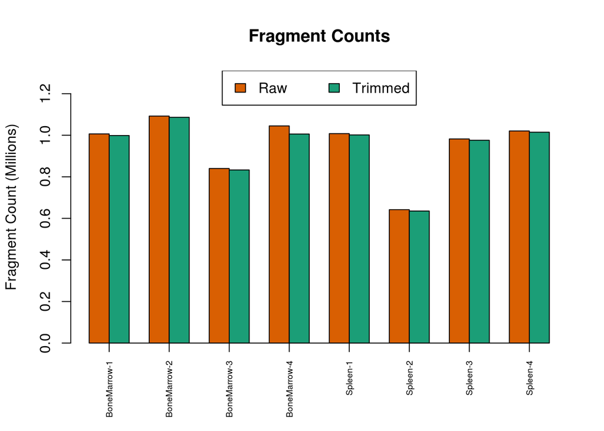

## 2.3 Read Quality Plots

### 2.3.1 Raw Reads

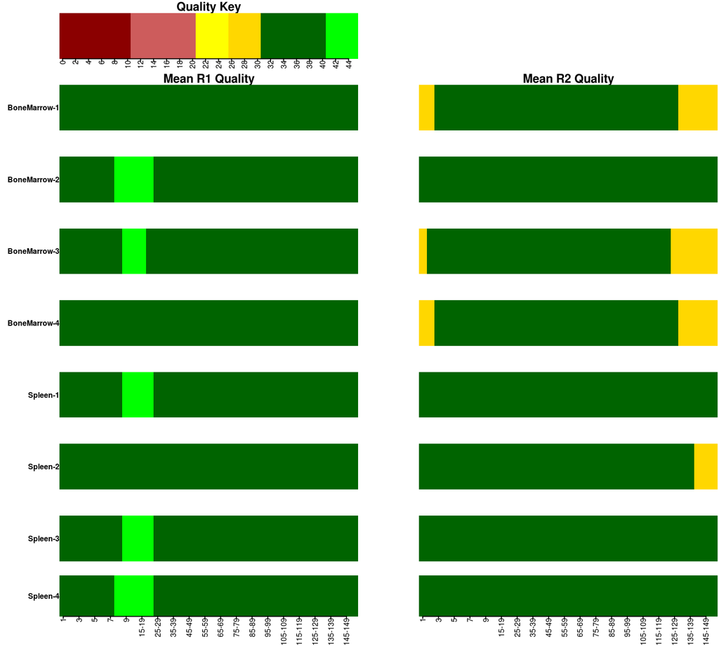

### 2.3.2 Trimmed Reads

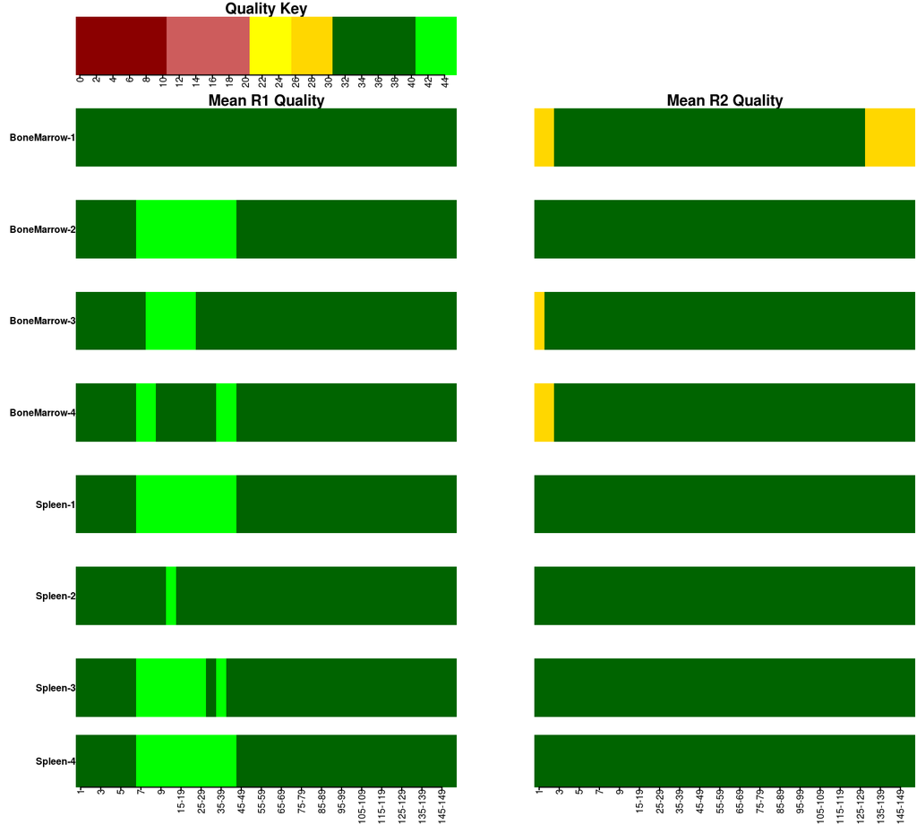

## 2.4 HISAT2 Plots

### 2.4.1 Fragment Counts Plot

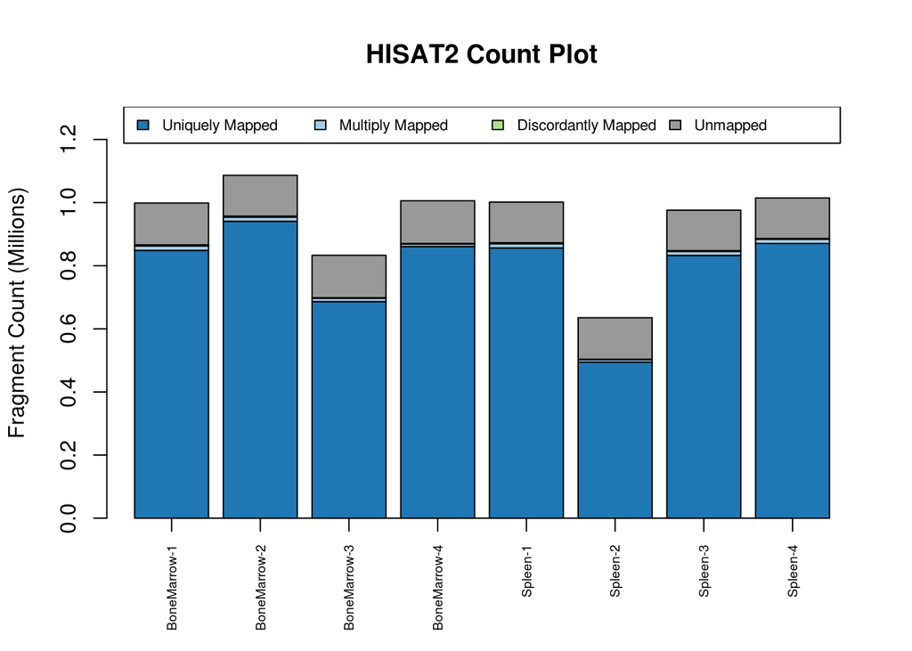

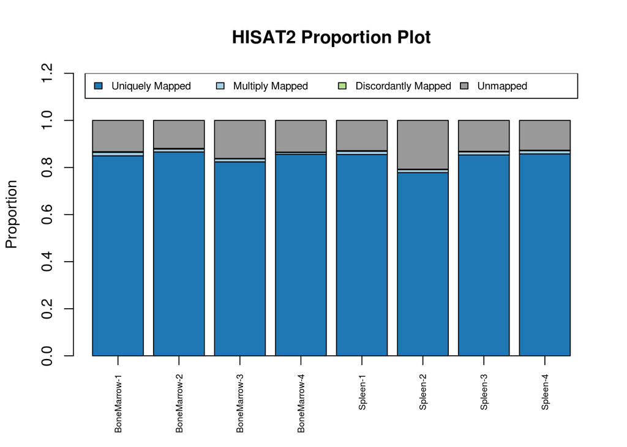

## 2.5 Expression Plots

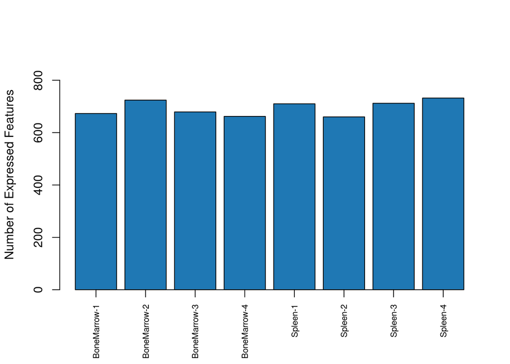

### 2.5.1 CPM

[figure not shown]

### 2.5.2 Clustering Heatmap

[figure not shown]

### 2.5.3 MDS

[figure not shown]

## 2.6 DEG Summary

Top 10 DEGs at the 0.05 FDR for S-B

[output not shown]

# 3 Run Summary

## 3.1 General Workflow

### 3.1.1 Read QC

A subsample of 10,000 reads or read pairs were sampled from each sample's reads. This subsample of 10,000 reads was searched for contamination from ribosomal RNA using a representative rRNA sequence list from the SILVA database release 132. Raw reads were summarized with FastQC, and optionally trimmed with Trimmomatic. If trimmed, the cleaned reads are re-assessed with FastQC. Length, quality, and duplication metrics were extracted from each FastQC run.

### 3.1.2 Alignment

Trimmed reads (or raw reads, if `--no-trim` was specified) were aligned to the reference genome with HISAT2. Duplicate reads based on alignment position were marked with SAMTools. If `--rmdup` was specified, then the positional duplicates were removed instead of marked. Alignments with duplicates marked were summarized with RNASeQC to quantify the proportion of positional duplicates, identify risosomal alignments, and quantify the proportion of "on-target" reads. Processed alignments were filtered of reads that have a mapping quality of less than 60, and sorted by query name rather than position.

### 3.1.3 Counts and Differential Expression testing

Cleaned and name-sorted alignments were processed with the featureCounts tool from the subread package. Fragments were counted in a strand-specific manner, unless the `--strand U` option was passed for a library that was prepared in a strand-unspecific way. Both mates of a read pair were required to map to a feature to be counted, if the data were paired-end.

Raw counts were imported into the `edgeR` package in R. Gnees that are shorter than the specified minimum length (`--min-len` argument, default 200bp) were pruned from the counts matrix before differential expression testing. If experimental groups were specified (`-e` argument), then the differential expression testing was peformed with a quasi-likelihood test in `edgeR` between all pairwise combinations of groups. A 0.05 false discovery rate correction was applied to the tests.

## 3.2 Results and Intermediate Files

### 3.2.1 Output Directory

The output directory is located at

`/scratch.global/konox006/RNASeq_Tutorial_Out`

This directory contains final results files and log files for the pipeline. Be sure to save these files if you would like to keep them. However, the pipeline script and samplesheet (reproduced below) are sufficient to recreate all output files. It will just require additional compute time and service units. The following directories are of interest:

- `/scratch.global/konox006/RNASeq_Tutorial_Out/Counts`

  Contains raw and CPM-transformed counts for each gene in the supplied GTF annotation.
- `/scratch.global/konox006/RNASeq_Tutorial_Out/DEGs`

  Contains a list of significantly differentially expressed genes, if experimental groups were supplied. If differential expression analysis was conducted, but no genes passed thresholds for significance, then the files will only have a header. Pairwise combinations of groups are tested for significance, so this directory may contain multiple files.
- `/scratch.global/konox006/RNASeq_Tutorial_Out/Coordinate_Sorted_BAMs`

  Contains BAM alignments sorted on alignment coordinates and BAM index files for loading into IGV or other alignment visualization tools. There are both pre-filtered (`*markdup.bam` or `*rmdup.bam`) and post-filtered (`*Filtered_CoordSort.bam`) files. In this case, the filtering is performed on mapping quality.
- `/scratch.global/konox006/RNASeq_Tutorial_Out/Dup_Stats`

  Contains per-read (2 files per sample for paired-end data) summaries of duplication levels in *raw* reads. These are extracted directly from the FastQC data file.
- `/scratch.global/konox006/RNASeq_Tutorial_Out/RNASeqMetrics`

  Contains per-sample output files from Picard CollectRnaSeqMetrics from the pre-filtering BAM file. There are also per-sample metaplots of coverage bias across the transcripts.
- `/scratch.global/konox006/RNASeq_Tutorial_Out/InsertSizeMetrics`

  Contains per-sample insert size summaries from Picard tools. The mean, median, and standard deviation are summarized in a table in the "Alignment Summaries" section of this report.
- `/scratch.global/konox006/RNASeq_Tutorial_Out/Logs`

  Contains per-sample run logs for read QC, trimming, and alignment. Also contains a log file for counting reads and performing differential expression testing.
- `/scratch.global/konox006/RNASeq_Tutorial_Out/Plots`

  Contains PDF vector images of DEG testing summary plots. The plots are also embedded into the "Counts Summaries" subsection of the "Alignment Summaries" section of this report.

### 3.2.2 Work Directory

The work directory is located at

`/scratch.global/konox006/RNASeq_Tutorial_Work`

This directory contains intermediate files for the pipeline. Be sure to save these files if you would like to refer to them in the future. However, the pipeline script and samplesheet (reproduced below) are sufficient to recreate all intermediate files for the pipeline. The work directory contains the following:

- `/scratch.global/konox006/RNASeq_Tutorial_Work/allsamples`

  Summary files used to generate this report and final BAM files used for generating raw counts.
- `/scratch.global/konox006/RNASeq_Tutorial_Work/singlesamples`

  Sub-directories, one for each sample, with FastQC reports, trimmed reads, intermediate SAM and BAM files, and alignment summary files. Refer to these if you would like to see the details of one particular sample. For example, if one sample has unexpected expression values, it may be because the sample is of low quality; this would be apparent in the read quality reports and the alignment summaries that are found in its work directory.

## 3.3 Pipeline Script

The path to the pipeline script is `/scratch.global/konox006/RNASeq_Tutorial_Out/2019-10-10.konox006.bulk_rnaseq.pipeline.sh`

The pipeline script is printed below. You may copy and paste the following script into a new plain text document to recreate the analyses run here. Be sure to save it with UNIX line endings (`LF` rather than `CR` [Mac] or `CRLF` [Windows] line endings), or else it will cause errors on Mesabi. Also be sure to turn off "smart quotes" and "smart dashes" on any text editors that you use to paste the following script. Smart quotes and smart dashes are not interpreted correctly by the shell on Mesabi and will also cause errors.

**Click to show pipeline script**

[output not shown]

## 3.4 Samplesheet

The path to the samplesheet is `/scratch.global/konox006/RNASeq_Tutorial_Out/2019-10-10.konox006.bulk_rnaseq.samplesheet.txt`

The samplesheet is printed below, verbatim. It is cumbersome to read, but you may copy and paste it into a plain text document to recreate the analyses run here. Like the pipeline script, be sure to save it with UNIX line endings (`LF` rather than `CR` [Mac] or `CRLF` [Windows]). Be sure to disable "smart quotes" and "smart dashes" on the text editor.

**Click to show samplesheet**

[output not shown]

The raw samplesheet is difficult to read, so we will print out a readable summary below:

|  | Sample Name | Group | R1 | R2 | Trim? | Remove Dups? | Trimmomatic Options | Reference Genome | HISAT2 Options | Strand | GTF Name |
| --- | --- | --- | --- | --- | --- | --- | --- | --- | --- | --- | --- |
| 1 | BoneMarrow-1 | B | BoneMarrow-1_S23_R1_001.fastq.gz | BoneMarrow-1_S23_R2_001.fastq.gz | yes | no | ILLUMINACLIP:$TRIMMOMATIC/adapters/all_illumina_adapters.fa:4:15:7:2:true LEADING:3 TRAILING:3 SLIDINGWINDOW:4:15 MINLEN:18 | GRCm38_19 | -p 4 --no-mixed --new-summary | 0 | Annotations.gtf.gz |
| 2 | BoneMarrow-2 | S | BoneMarrow-2_S21_R1_001.fastq.gz | BoneMarrow-2_S21_R2_001.fastq.gz | yes | no | ILLUMINACLIP:$TRIMMOMATIC/adapters/all_illumina_adapters.fa:4:15:7:2:true LEADING:3 TRAILING:3 SLIDINGWINDOW:4:15 MINLEN:18 | GRCm38_19 | -p 4 --no-mixed --new-summary | 0 | Annotations.gtf.gz |
| 3 | BoneMarrow-3 | B | BoneMarrow-3_S19_R1_001.fastq.gz | BoneMarrow-3_S19_R2_001.fastq.gz | yes | no | ILLUMINACLIP:$TRIMMOMATIC/adapters/all_illumina_adapters.fa:4:15:7:2:true LEADING:3 TRAILING:3 SLIDINGWINDOW:4:15 MINLEN:18 | GRCm38_19 | -p 4 --no-mixed --new-summary | 0 | Annotations.gtf.gz |
| 4 | BoneMarrow-4 | B | BoneMarrow-4_S17_R1_001.fastq.gz | BoneMarrow-4_S17_R2_001.fastq.gz | yes | no | ILLUMINACLIP:$TRIMMOMATIC/adapters/all_illumina_adapters.fa:4:15:7:2:true LEADING:3 TRAILING:3 SLIDINGWINDOW:4:15 MINLEN:18 | GRCm38_19 | -p 4 --no-mixed --new-summary | 0 | Annotations.gtf.gz |
| 5 | Spleen-1 | S | Spleen-1_S31_R1_001.fastq.gz | Spleen-1_S31_R2_001.fastq.gz | yes | no | ILLUMINACLIP:$TRIMMOMATIC/adapters/all_illumina_adapters.fa:4:15:7:2:true LEADING:3 TRAILING:3 SLIDINGWINDOW:4:15 MINLEN:18 | GRCm38_19 | -p 4 --no-mixed --new-summary | 0 | Annotations.gtf.gz |
| 6 | Spleen-2 | S | Spleen-2_S29_R1_001.fastq.gz | Spleen-2_S29_R2_001.fastq.gz | yes | no | ILLUMINACLIP:$TRIMMOMATIC/adapters/all_illumina_adapters.fa:4:15:7:2:true LEADING:3 TRAILING:3 SLIDINGWINDOW:4:15 MINLEN:18 | GRCm38_19 | -p 4 --no-mixed --new-summary | 0 | Annotations.gtf.gz |
| 7 | Spleen-3 | S | Spleen-3_S27_R1_001.fastq.gz | Spleen-3_S27_R2_001.fastq.gz | yes | no | ILLUMINACLIP:$TRIMMOMATIC/adapters/all_illumina_adapters.fa:4:15:7:2:true LEADING:3 TRAILING:3 SLIDINGWINDOW:4:15 MINLEN:18 | GRCm38_19 | -p 4 --no-mixed --new-summary | 0 | Annotations.gtf.gz |
| 8 | Spleen-4 | S | Spleen-4_S25_R1_001.fastq.gz | Spleen-4_S25_R2_001.fastq.gz | yes | no | ILLUMINACLIP:$TRIMMOMATIC/adapters/all_illumina_adapters.fa:4:15:7:2:true LEADING:3 TRAILING:3 SLIDINGWINDOW:4:15 MINLEN:18 | GRCm38_19 | -p 4 --no-mixed --new-summary | 0 | Annotations.gtf.gz |

## 3.5 Software Environment

### 3.5.1 Single Sample Job Modules

This is the full list of loaded modules for each single-sample job, which includes read trimming and read mapping.

```
python3/3.6.3_anaconda5.0.1
hisat2/2.1.0
/panfs/roc/soft/modulefiles.legacy/modulefiles.common/java/jdk1.7.0_45
fastqc/0.11.7
trimmomatic/0.33
xz-utils/5.2.3_gcc7.2.0
bzip2/1.0.6-gnu6.1.0_PIC
gmp/6.1.2_gcc7.2.0
mpfr/3.1.6_gcc7.2.0
mpc/1.0.3_gcc7.2.0
isl/0.18_gcc7.2.0
gcc/7.2.0
samtools/1.7
/panfs/roc/soft/modulefiles.legacy/modulefiles.common/java/jdk1.8.0_45
picard/2.9.0
zlib/1.2.11_gcc7.2.0
bzip2/1.0.6-gnu7.2.0_PIC
pcre/8.42_gcc7.2.0
curl/7.59.0_gcc7.2.0
gmp/6.1.2_gcc8.1.0
mpfr/4.0.1_gcc8.1.0
mpc/1.1.0_gcc8.1.0
isl/0.19_gcc8.1.0
gcc/8.1.0
libtiff/4.0.8
R/3.5.0
java/openjdk-11.0.2
```

### 3.5.2 Summary Job Modules

This is the full list of loaded modules for the summary job, which includes counting and differential expression testing.

```
zlib/1.2.11_gcc7.2.0
bzip2/1.0.6-gnu7.2.0_PIC
gmp/6.1.2_gcc7.2.0
mpfr/3.1.6_gcc7.2.0
mpc/1.0.3_gcc7.2.0
isl/0.18_gcc7.2.0
gcc/7.2.0
pcre/8.42_gcc7.2.0
xz-utils/5.2.3_gcc7.2.0
curl/7.59.0_gcc7.2.0
gmp/6.1.2_gcc8.1.0
mpfr/4.0.1_gcc8.1.0
mpc/1.1.0_gcc8.1.0
isl/0.19_gcc8.1.0
gcc/8.1.0
libtiff/4.0.8
R/3.5.0
python/3.6.3
```

# 4 QC Metrics

## 4.1 Read Counts

Read count summary.

| Sample Name | Raw R1 Count | Raw R2 Count | Trimmed R1 Count | Trimmed R2 Count |
| --- | --- | --- | --- | --- |
| BoneMarrow-1 | 1006504 | 1006504 | 998695 | 998695 |
| BoneMarrow-2 | 1092217 | 1092217 | 1086386 | 1086386 |
| BoneMarrow-3 | 840077 | 840077 | 833111 | 833111 |
| BoneMarrow-4 | 1044925 | 1044925 | 1005803 | 1005803 |
| Spleen-1 | 1007898 | 1007898 | 1001505 | 1001505 |
| Spleen-2 | 641889 | 641889 | 635273 | 635273 |
| Spleen-3 | 982184 | 982184 | 975857 | 975857 |
| Spleen-4 | 1020670 | 1020670 | 1014689 | 1014689 |

## 4.2 rRNA Contamination (Based on Kmer Matching)

These counts were based on searching a subset of the raw reads against a reference database of ribosomal K-mers. Click on the table headers to show the summaries of rRNA contamination.

### 4.2.1 Plot

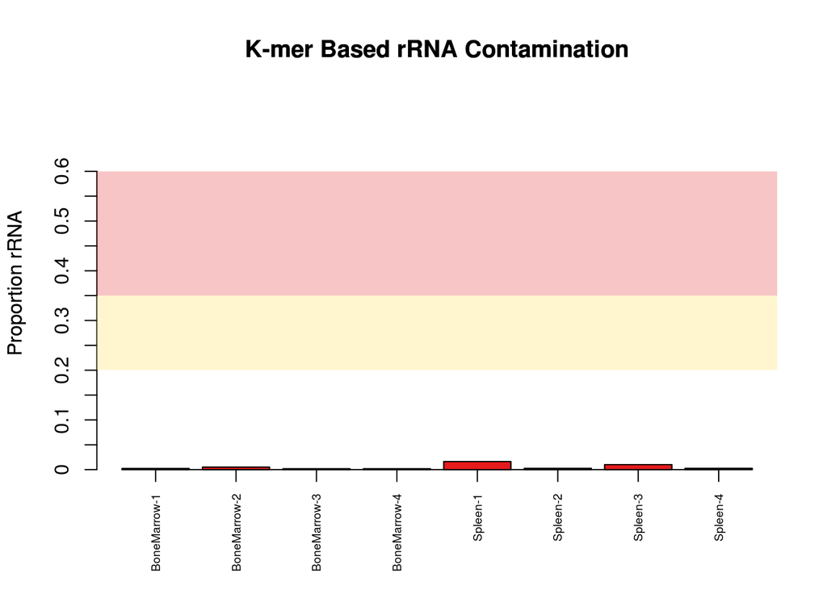

### 4.2.2 Table

Number of read pairs (from subsample) and percentage of library that is estimated to be derived from ribosomal RNA.

| SampleName | rRNA_Fragments | rRNA_Pct |
| --- | --- | --- |
| BoneMarrow-1 | 40 | 0.20000% |
| BoneMarrow-2 | 99 | 0.49500% |
| BoneMarrow-3 | 34 | 0.17000% |
| BoneMarrow-4 | 34 | 0.17000% |
| Spleen-1 | 325 | 1.62500% |
| Spleen-2 | 48 | 0.24000% |
| Spleen-3 | 202 | 1.01000% |
| Spleen-4 | 50 | 0.25000% |

## 4.3 Mapping-based QC Metrics

These plots show QC metrics based on summaries of the BAM alignment files, as generated by [RNASeQC](https://github.com/broadinstitute/rnaseqc).

### 4.3.1 Expression Profiling Efficiency

This plot shows the proportion of high-quality alignments that are in exons. For messenger RNA libraries, this value is expected to be close to 1.

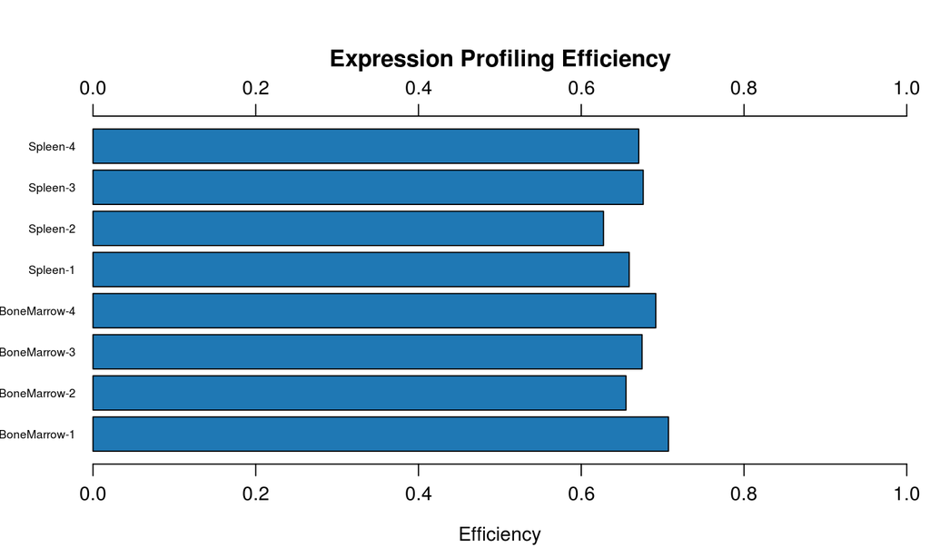

### 4.3.2 Duplication

This plot shows the proportion of alignments that are positional duplicates in each sample, as determined in the default algorithm of the [Picard MarkDuplicates](https://broadinstitute.github.io/picard/command-line-overview.html#MarkDuplicates) tool.

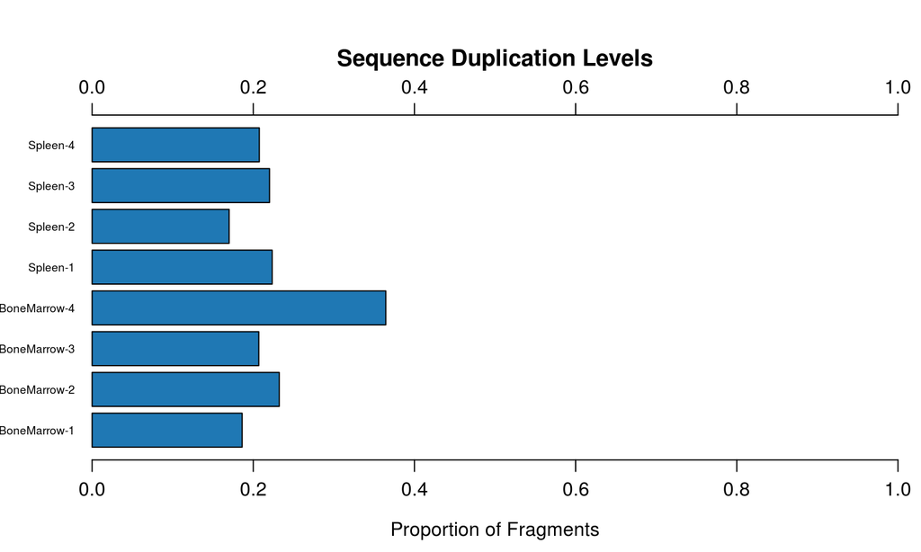

### 4.3.3 gDNA and Strand Agreement

These plots show both gDNA contamination and strand-specificity. The plot on the left shows the read alignments to exons, introns, and to intergenic regions while accounting for the strand of the annotations. The plot on the right shows the same region-based summary, but ignoring the strand of the annotations. If the unstranded plot shows much higher assignment to exons than the strand-aware plot, then it is likely that you have given the incorrect strand-specificity for your library. Please refer to the library preparation protocol to determine the correct strand-specificity.

If the plots look similar in terms of assignment proportions, then you have given the correct strand-specificity.

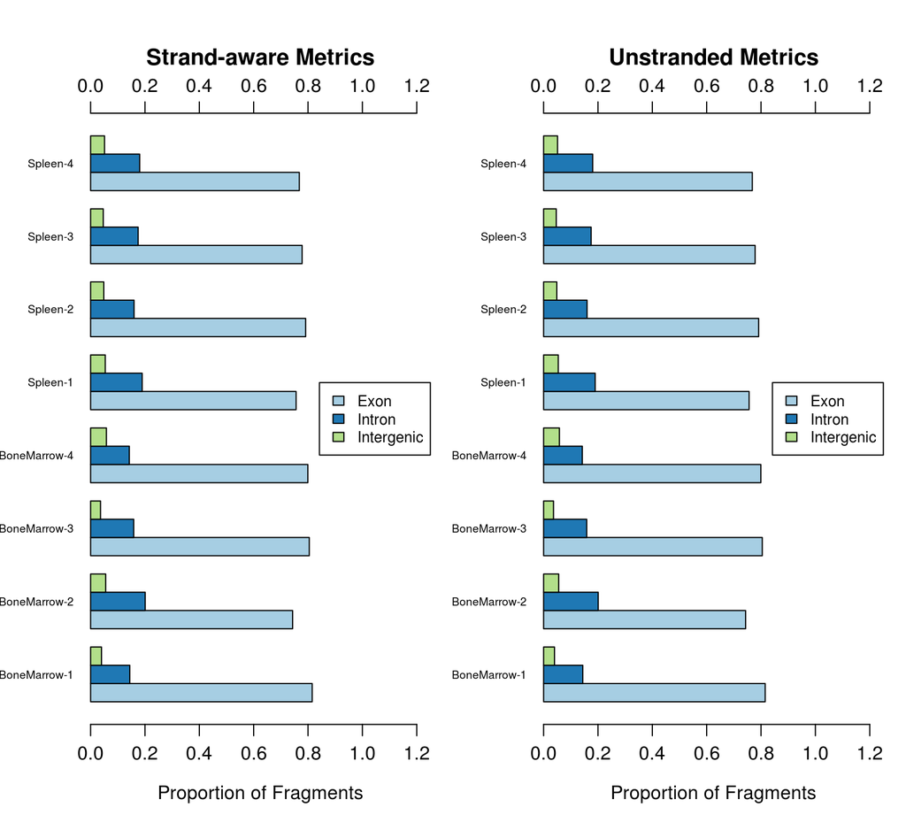

### 4.3.4 rRNA

This plot shows the proportion of alignments that are in annotated rRNA features.

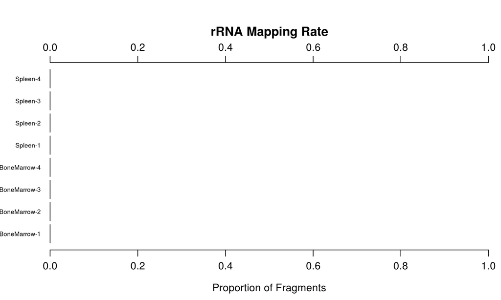

## 4.4 Read Qualities

Click on the tab headers to show plots of raw and trimmed read qualities.

### 4.4.1 Raw Read Qualities (Compact style)

These plots show the read qualities as they came off the sequencing instrument.

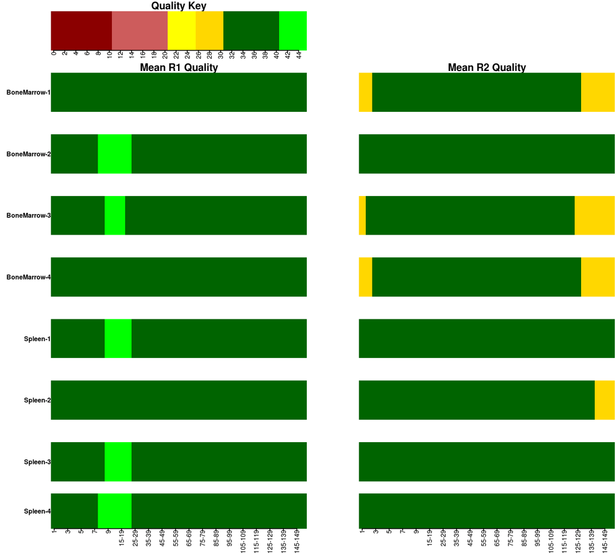

### 4.4.2 Trimmed Read Qualities (Compact style)

These plots show read qualities post-trimming, if it was performed.

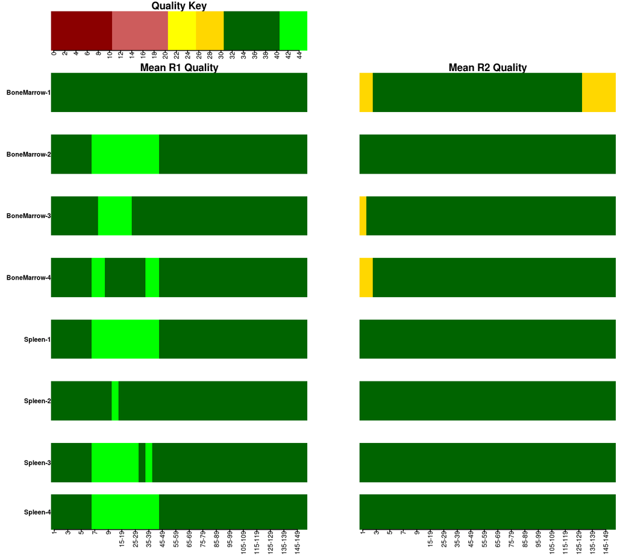

### 4.4.3 Raw Read Qualities (FastQC-style)

The plots below show the variance in quality across the reads for each sample. The black dot shows the mean quality, the red dot shows the median quality, the grey shaded region shows the inter-quartile range, and the vertical black lines show the 10th-90th percentile range.

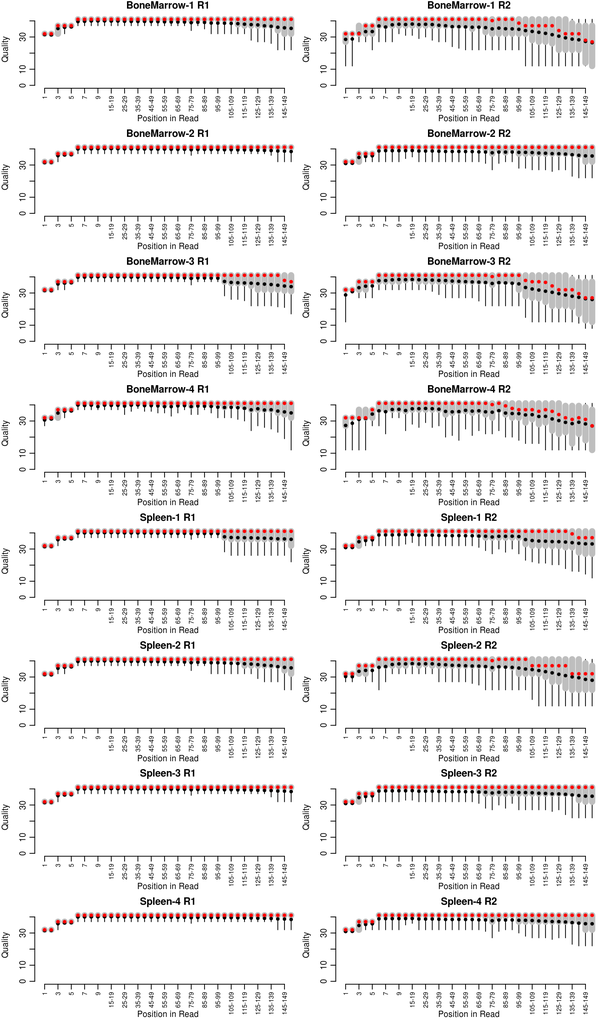

### 4.4.4 Trimmed Read Qualities (FastQC-style)

The plots below show the variance in quality across the reads for each sample. The black dot shows the mean quality, the red dot shows the median quality, the grey shaded region shows the inter-quartile range, and the vertical black lines show the 10th-90th percentile range.

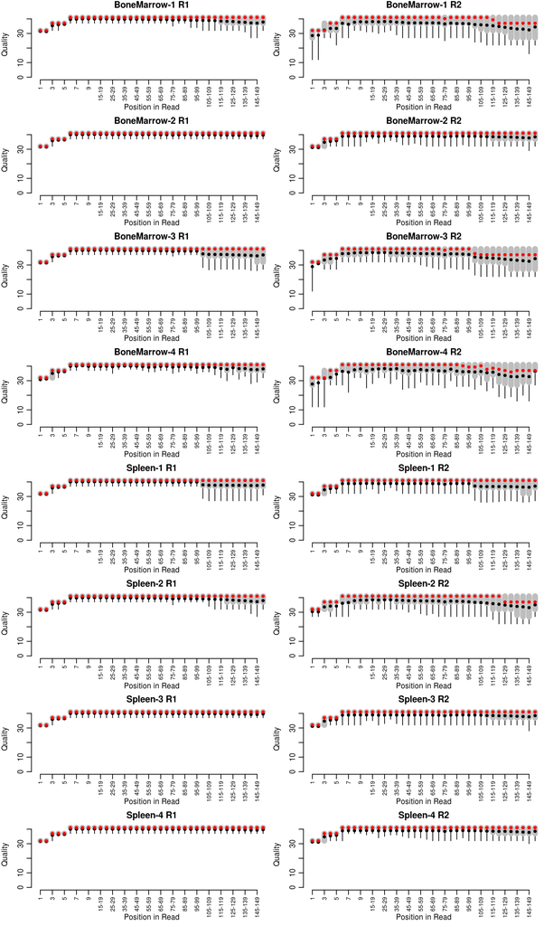

# 5 Alignment Summaries

## 5.1 HISAT2 Summaries

### 5.1.1 Counts-Based

These plots summarize the number of fragments that align uniquely, multiply, discordantly, or do not map to the genome.

#### 5.1.1.1 Plot

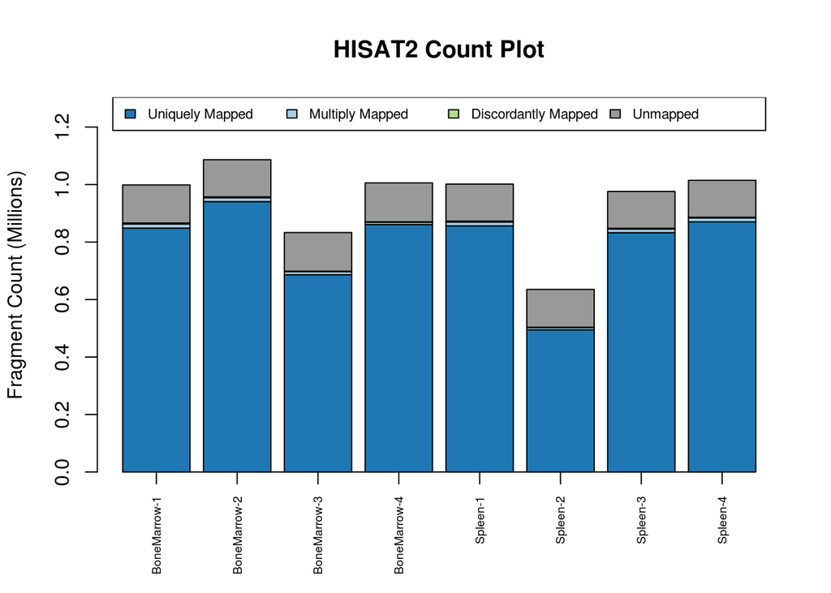

Summary of alignment from HISAT2 based on fragment counts. Note that if the samples are paired-end, then each fragment is represented by 2 reads. If the samples are single-end, then each fragment is represented by 1 read.

| Sample Name | Total Fragments | Unmapped | Uniquely Mapped | Multiply Mapped | Discordantly Mapped |
| --- | --- | --- | --- | --- | --- |
| BoneMarrow-1 | 998695 | 132530 | 848540 | 14399 | 3226 |
| BoneMarrow-2 | 1086386 | 129107 | 940791 | 13172 | 3316 |
| BoneMarrow-3 | 833111 | 134480 | 686356 | 10594 | 1681 |
| BoneMarrow-4 | 1005803 | 135440 | 860969 | 7734 | 1660 |
| Spleen-1 | 1001505 | 128676 | 856390 | 13320 | 3119 |
| Spleen-2 | 635273 | 131605 | 494392 | 8037 | 1239 |
| Spleen-3 | 975857 | 128003 | 832630 | 12701 | 2523 |
| Spleen-4 | 1014689 | 128485 | 870373 | 13196 | 2635 |

### 5.1.2 Proportion-Based

These plots summarize the mapping as a proportion of the total reads.

#### 5.1.2.1 Plot

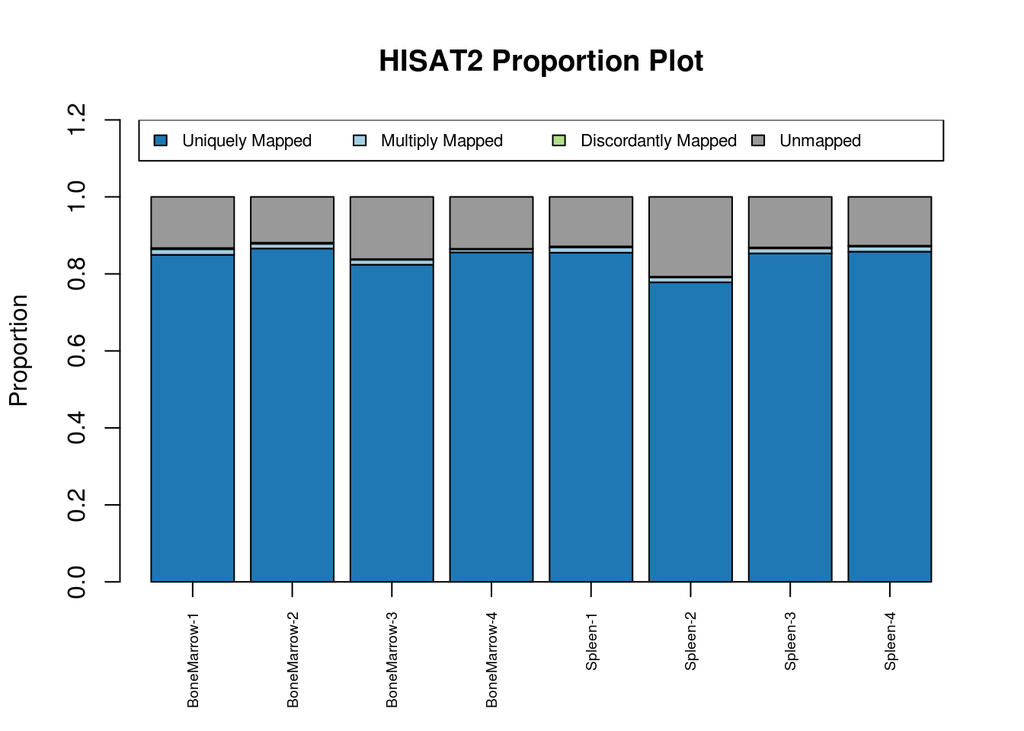

Summary of alignment from HISAT2 based on percentage of total reads. Note that if the samples are paired-end, then each fragment is represented by 2 reads. If the samples are single-end, then each fragment is represented by 1 read.

| Sample Name | Total Fragments | Unmapped | Uniquely Mapped | Multiply Mapped | Discordantly Mapped |
| --- | --- | --- | --- | --- | --- |
| BoneMarrow-1 | 100% | 13.27% | 84.96% | 1.44% | 0.32% |
| BoneMarrow-2 | 100% | 11.88% | 86.6% | 1.21% | 0.31% |
| BoneMarrow-3 | 100% | 16.14% | 82.38% | 1.27% | 0.2% |
| BoneMarrow-4 | 100% | 13.47% | 85.6% | 0.77% | 0.17% |
| Spleen-1 | 100% | 12.85% | 85.51% | 1.33% | 0.31% |
| Spleen-2 | 100% | 20.72% | 77.82% | 1.27% | 0.2% |
| Spleen-3 | 100% | 13.12% | 85.32% | 1.3% | 0.26% |
| Spleen-4 | 100% | 12.66% | 85.78% | 1.3% | 0.26% |

## 5.2 Mapping Statistics

The following table summarizes alignment characteristics with the output from `samtools stats`.

Summary of read mapping from SAMTools. *Note that this counts reads and not fragments.

| Sample Name | Reads Mapped* | PCR Duplicate | MAPQ = 0 | Max Read Length | Average Read Length | Average Read Quality |
| --- | --- | --- | --- | --- | --- | --- |
| BoneMarrow-1 | 1997390 | 322482 | 886 | 150 | 136 | 37.7 |
| BoneMarrow-2 | 2172772 | 444630 | 484 | 150 | 144 | 39.1 |
| BoneMarrow-3 | 1666222 | 289006 | 456 | 150 | 137 | 37.7 |
| BoneMarrow-4 | 2011606 | 634418 | 554 | 150 | 139 | 37.7 |
| Spleen-1 | 2003010 | 390088 | 322 | 150 | 142 | 38.5 |
| Spleen-2 | 1270546 | 171316 | 414 | 150 | 139 | 38.0 |
| Spleen-3 | 1951714 | 373332 | 406 | 150 | 144 | 39.1 |
| Spleen-4 | 2029378 | 367768 | 410 | 150 | 144 | 39.1 |

## 5.3 Insert Size Metrics

The plot below shows the variance in insert size for each sample. The black dot shows the mean insert size, the red dot shows the median insert size, the grey shaded region shows the bin that encompasses 30% of the insert sizes, and the black lines show the bin that encompasses 90% of the insert sizes.

The bin widths reported in the table are widths of intervals, centered around the median, that encompass a certain percentage of the insert sizes. For a full description of the bin widths, see the [Picard Documentation](https://broadinstitute.github.io/picard/picard-metric-definitions.html#InsertSizeMetrics).

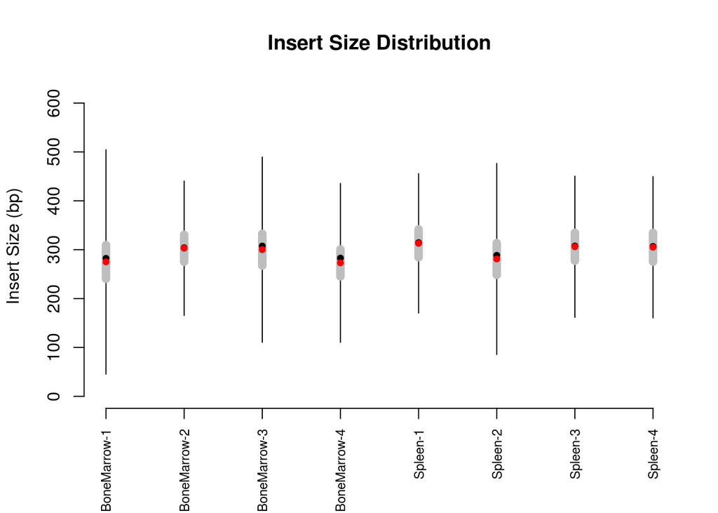

Insert size summary.

| Sample Name | Median Insert Size | Mean Insert Size | Insert Size StdDev | Width of 10% Bin | Width of 30% Bin | Width of 70% Bin | Width of 90% Bin |
| --- | --- | --- | --- | --- | --- | --- | --- |
| BoneMarrow-1 | 275 | 282.291 | 104.935 | 23 | 69 | 193 | 459 |
| BoneMarrow-2 | 303 | 304.034 | 80.940 | 19 | 55 | 157 | 275 |
| BoneMarrow-3 | 300 | 307.504 | 99.824 | 21 | 65 | 185 | 379 |
| BoneMarrow-4 | 273 | 282.779 | 91.260 | 23 | 55 | 165 | 325 |
| Spleen-1 | 313 | 314.415 | 82.937 | 19 | 57 | 161 | 285 |
| Spleen-2 | 281 | 288.430 | 97.031 | 21 | 65 | 179 | 391 |
| Spleen-3 | 306 | 307.497 | 84.535 | 19 | 57 | 163 | 289 |
| Spleen-4 | 305 | 306.712 | 84.622 | 19 | 59 | 165 | 289 |

## 5.4 Counts Summaries

### 5.4.1 Subread Assignment Summary

These plots will show the breakdown of read assignment by `featureCounts`.

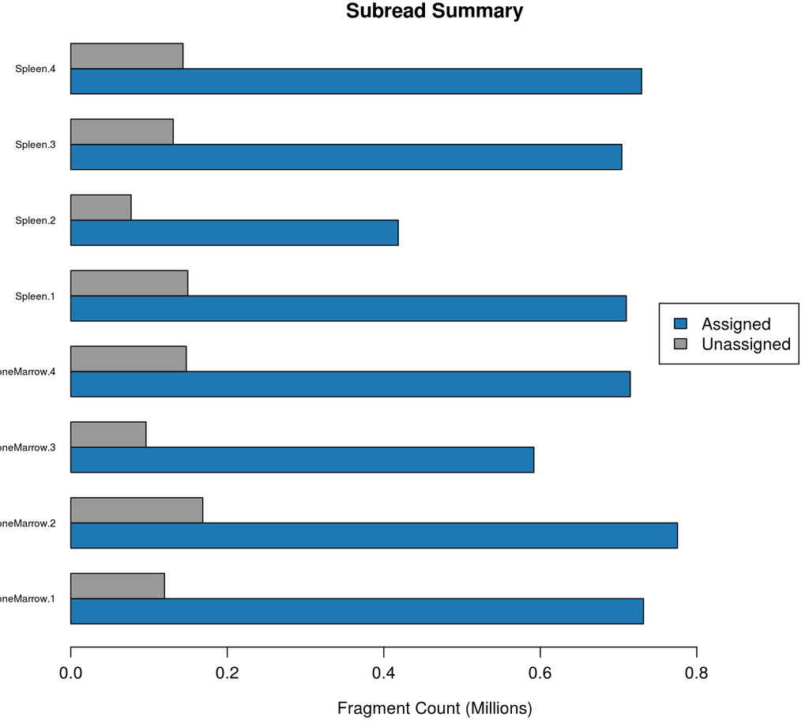

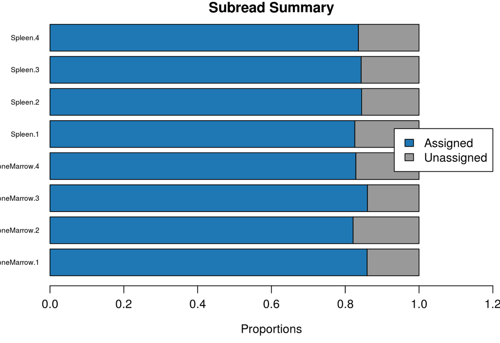

|  | Assigned | Unassigned_Unmapped | Unassigned_MappingQuality | Unassigned_Chimera | Unassigned_FragmentLength | Unassigned_Duplicate | Unassigned_MultiMapping | Unassigned_Secondary | Unassigned_Nonjunction | Unassigned_NoFeatures | Unassigned_Overlapping_Length | Unassigned_Ambiguity |
| --- | --- | --- | --- | --- | --- | --- | --- | --- | --- | --- | --- | --- |
| BoneMarrow.1 | 731944 | 0 | 0 | 0 | 0 | 0 | 0 | 0 | 0 | 96957 | 0 | 22865 |
| BoneMarrow.2 | 775410 | 0 | 0 | 0 | 0 | 0 | 0 | 0 | 0 | 149189 | 0 | 19508 |
| BoneMarrow.3 | 591842 | 0 | 0 | 0 | 0 | 0 | 0 | 0 | 0 | 80677 | 0 | 15518 |
| BoneMarrow.4 | 715001 | 0 | 0 | 0 | 0 | 0 | 0 | 0 | 0 | 135095 | 0 | 12533 |
| Spleen.1 | 709948 | 0 | 0 | 0 | 0 | 0 | 0 | 0 | 0 | 130518 | 0 | 19043 |
| Spleen.2 | 418543 | 0 | 0 | 0 | 0 | 0 | 0 | 0 | 0 | 65667 | 0 | 11421 |
| Spleen.3 | 704223 | 0 | 0 | 0 | 0 | 0 | 0 | 0 | 0 | 112183 | 0 | 18747 |
| Spleen.4 | 729557 | 0 | 0 | 0 | 0 | 0 | 0 | 0 | 0 | 124879 | 0 | 18572 |

### 5.4.2 Number of Expressed Features

This plot shows the number of features (genes) that have at least one fragment mapping to them.

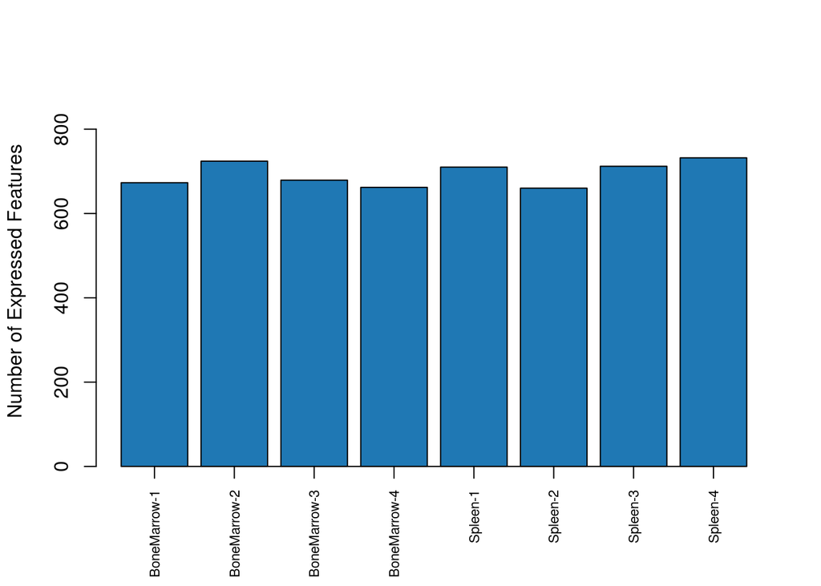

### 5.4.3 Expression in Counts-per-million

Shown below is a distribution of expression values as log2(1+CPM). CPM (counts-per-million) is a transformation of raw counts that accounts for the number of fragments sequenced in the library, like FPKM. It does not account for gene length like FPKM, however. You can compare CPM values for the same gene across samples, but do not compare CPM values for different genes in the same sample.

[figure not shown]

### 5.4.4 Sample Clustering Heatmap

We then calculated the variance in CPM values for each gene across the sequenced samples. The 500 genes with the highest variance in expression were used to generate the following heatmap:

[figure not shown]

### 5.4.5 Multidimensional Scaling Plot

CPM values were then used to generate a multidimensional scaling (MDS) plot, which functions similarly to a principal components plot:

[figure not shown]

# 6 DEG Testing

If experimental groups were supplied, we test for differential expression among them with a quasi-likelihood test (using `glmQLFit` in `edgeR`). We apply a `0.05` false discovery rate correction to the differential expression tests. If you did not supply experimental groups, then this section will mostly be empty.

## 6.1 Experimental Groups

The following experimental groups were supplied to the pipeline. These are read out of the samplesheet:

Experimental groups.

| Sample Name | Group |
| --- | --- |
| BoneMarrow-1 | B |
| BoneMarrow-2 | S |
| BoneMarrow-3 | B |
| BoneMarrow-4 | B |
| Spleen-1 | S |
| Spleen-2 | S |
| Spleen-3 | S |
| Spleen-4 | S |

## 6.2 DEG List

The top differentially expressed genes (DEGs) are given below. Comparisons are reported as `Group2-Group1`, with `Group2` serving as the numerator for the fold change calculations. That is, if `logFC` is positive, then the gene has higher expression in `Group2` than in `Group1`. The files in the `DEGs/` directory under the output directory follow this naming convention: `DE_Group2-Group1_list.txt`.

**Note** that the group ordering is based on alphabetical sort order. This means that if you named your groups `Case` and `Control` then `Case` will be the **denominator** of the comparison. This is opposite to what is conventionally done; you must flip the signs on the log(Fold Change) values if you want to interpret the changes in the `Case` group with respect to the `Control` group. The P-values (both nominal and FDR-adjusted) and CPM values are unaffected.

Top DEGs at the 0.05 FDR for S-B

[output not shown]